# Transportation

## Vehicle Type, Trailer Towing, and Vehicle Occupancy

*Data presented on this page describe data from passengers who reported arriving to BRC via Gate or Point 1.*

## Vehicle Type (2018 Only)*

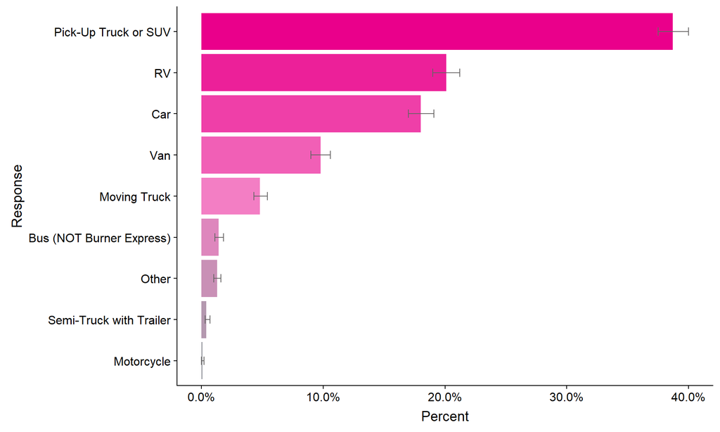

Error bars indicate the upper and lower bounds of the 95% confidence intervals.

* Data presented here represent responses from all participants who entered BRC via Gate or Point 1 in 2018.

|  | 2018 Percent | 2018 MoE +/- % |
| --- | --- | --- |
| Pick-Up Truck or SUV | 38.7 | 1.2 |
| RV | 20.1 | 1.2 |
| Car | 18.0 | 1.0 |
| Van | 9.8 | 0.8 |
| Moving Truck | 4.8 | 0.6 |
| Bus (NOT Burner Express) | 1.4 | 0.4 |
| Other | 1.3 | 0.4 |
| Semi-Truck with Trailer | 0.4 | 0.2 |
| Motorcycle | 0.1 | 0.0 |

*The answer options for this question in the online survey have undergone several edits over the last few years, so year-to-year comparison is impossible.*

## 2018 Trailer Towing

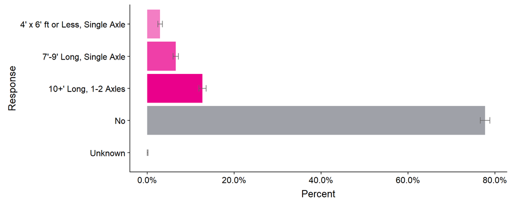

Error bars indicate the upper and lower bounds of the 95% confidence intervals.

* Data presented here represent responses from all participants who entered BRC via Gate or Point 1 who reported arriving in any vehicle type other than a "large semi-truck towing a trailer."

|  | 2018 Percent | 2018 MoE +/- % |
| --- | --- | --- |
| 4’ x 6’ ft or Less, Single Axle | 3.0 | 0.4 |
| 7’-9’ Long, Single Axle | 6.6 | 0.6 |
| 10+’ Long, 1-2 Axles | 12.7 | 0.8 |
| No | 77.7 | 1.2 |
| Unknown | 0.0 | 0.0 |

## Vehicle Occupancy

### Number of People in Vehicle*

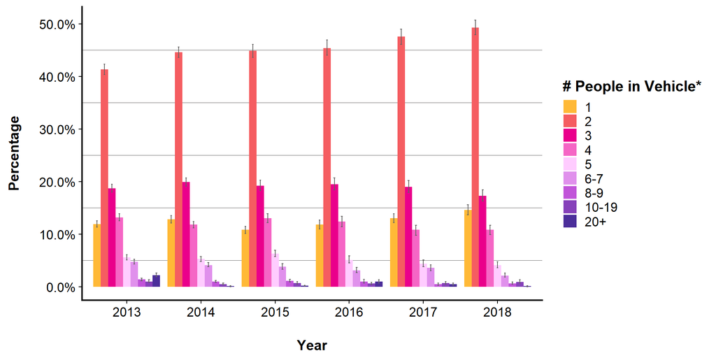

Error bars indicate the upper and lower bounds of the 95% confidence intervals.

* Data presented here represent responses from all participants who entered BRC via Gate or Point 1.

|  | 2013 Percent | 2013 MoE +/- % |  | 2014 Percent | 2014 MoE +/- % |  | 2015 Percent | 2015 MoE +/- % |  | 2016 Percent | 2016 MoE +/- % |  | 2017 Percent | 2017 MoE +/- % |  | 2018 Percent | 2018 MoE +/- % |
| --- | --- | --- | --- | --- | --- | --- | --- | --- | --- | --- | --- | --- | --- | --- | --- | --- | --- |
| 1 | 11.9 | 0.6 |  | 12.8 | 0.8 |  | 10.8 | 0.8 |  | 11.8 | 0.8 |  | 13.0 | 1.0 |  | 14.6 | 1.0 |
| 2 | 41.3 | 1.0 |  | 44.6 | 1.0 |  | 44.9 | 1.2 |  | 45.4 | 1.4 |  | 47.6 | 1.4 |  | 49.3 | 1.4 |
| 3 | 18.7 | 0.8 |  | 19.9 | 0.8 |  | 19.2 | 1.0 |  | 19.5 | 1.2 |  | 19.0 | 1.2 |  | 17.3 | 1.0 |
| 4 | 13.2 | 0.8 |  | 11.8 | 0.6 |  | 13.0 | 0.8 |  | 12.4 | 1.0 |  | 10.8 | 1.0 |  | 10.8 | 1.0 |
| 5 | 5.6 | 0.4 |  | 5.3 | 0.4 |  | 6.3 | 0.6 |  | 5.1 | 0.8 |  | 4.4 | 0.6 |  | 4.1 | 0.6 |
| 6-7 | 4.7 | 0.4 |  | 4.1 | 0.4 |  | 3.8 | 0.6 |  | 3.1 | 0.6 |  | 3.6 | 0.6 |  | 2.1 | 0.4 |
| 8-9 | 1.4 | 0.2 |  | 1.0 | 0.2 |  | 1.1 | 0.2 |  | 1.0 | 0.4 |  | 0.5 | 0.2 |  | 0.6 | 0.2 |
| 10-19 | 1.0 | 0.2 |  | 0.5 | 0.2 |  | 0.7 | 0.2 |  | 0.6 | 0.2 |  | 0.7 | 0.2 |  | 0.9 | 0.4 |
| 20+ | 2.2 | 0.4 |  | 0.1 | 0.0 |  | 0.2 | 0.0 |  | 1.0 | 0.2 |  | 0.5 | 0.2 |  | 0.1 | 0.0 |

## Vehicle Occupancy

### Number of Minors (0-17) in Vehicle*

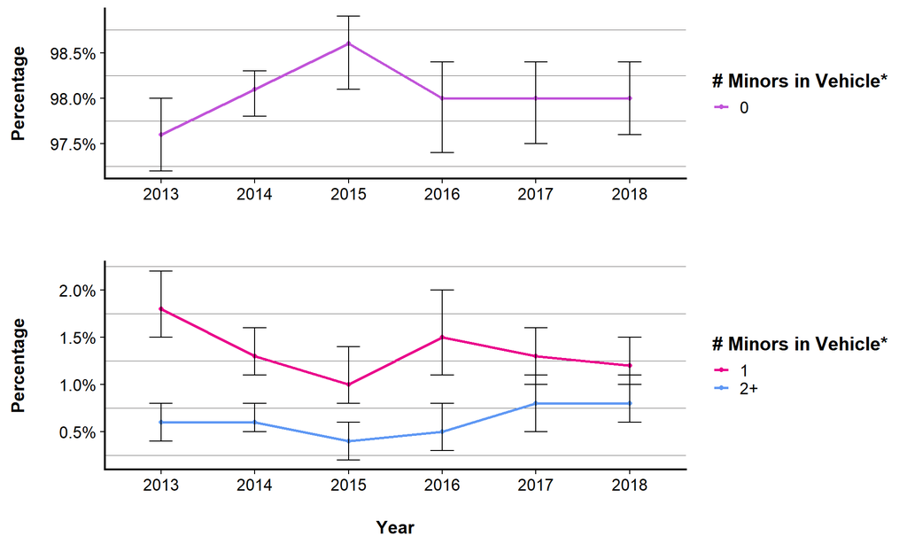

Error bars indicate the upper and lower bounds of the 95% confidence intervals.

* Data presented here represent responses from all participants who entered BRC via Gate or Point 1.

|  | 2013 Percent | 2013 MoE +/- % |  | 2014 Percent | 2014 MoE +/- % |  | 2015 Percent | 2015 MoE +/- % |  | 2016 Percent | 2016 MoE +/- % |  | 2017 Percent | 2017 MoE +/- % |  | 2018 Percent | 2018 MoE +/- % |
| --- | --- | --- | --- | --- | --- | --- | --- | --- | --- | --- | --- | --- | --- | --- | --- | --- | --- |
| 0 | 97.6 | 0.4 |  | 98.1 | 0.2 |  | 98.6 | 0.4 |  | 98.0 | 0.6 |  | 98.0 | 0.4 |  | 98.0 | 0.4 |
| 1 | 1.8 | 0.4 |  | 1.3 | 0.2 |  | 1.0 | 0.4 |  | 1.5 | 0.4 |  | 1.3 | 0.4 |  | 1.2 | 0.2 |
| 2+ | 0.6 | 0.2 |  | 0.6 | 0.2 |  | 0.4 | 0.2 |  | 0.5 | 0.2 |  | 0.8 | 0.4 |  | 0.8 | 0.2 |

**Next:** Transportation: Burner Express Bus